# Assignment 3

# **BUSINESS PROBLEM:**

#### Increase in Carbondioxide Emmissions(CO2) from food consumption.

#### Approximately 20 - 25% of greenhouse emissions is produced by food. People believe that CO2 is prosuced only by fuels and Industries. But it is also produced from the food we consume.

# **Main findings from the dataset:**

### *Can we predict the final CO2 emmission by knowing their consumption and food category?*

### Sub questions:

### *How many types of food_categories are there?*

### *What is the relation between the consumption and the final co2_emmission.*

### *What is the relation between the consumption and the final co2_emmission depending on food_category?*

### *How many types of food_categories are there?*

```r
food %>%
  count(food_category) %>%
  kable()
```

| food_category | n |
| --- | --- |
| Beef | 130 |
| Eggs | 130 |
| Fish | 130 |
| Lamb & Goat | 130 |
| Milk - inc. cheese | 130 |
| Nuts inc. Peanut Butter | 130 |
| Pork | 130 |
| Poultry | 130 |
| Rice | 130 |
| Soybeans | 130 |
| Wheat and Wheat Products | 130 |

```r
# using count function to display no of food categories
```

#### There are 11 food_categories with 130 observations in each.

### *What is the relation between the consumption and the final co2_emmission.*

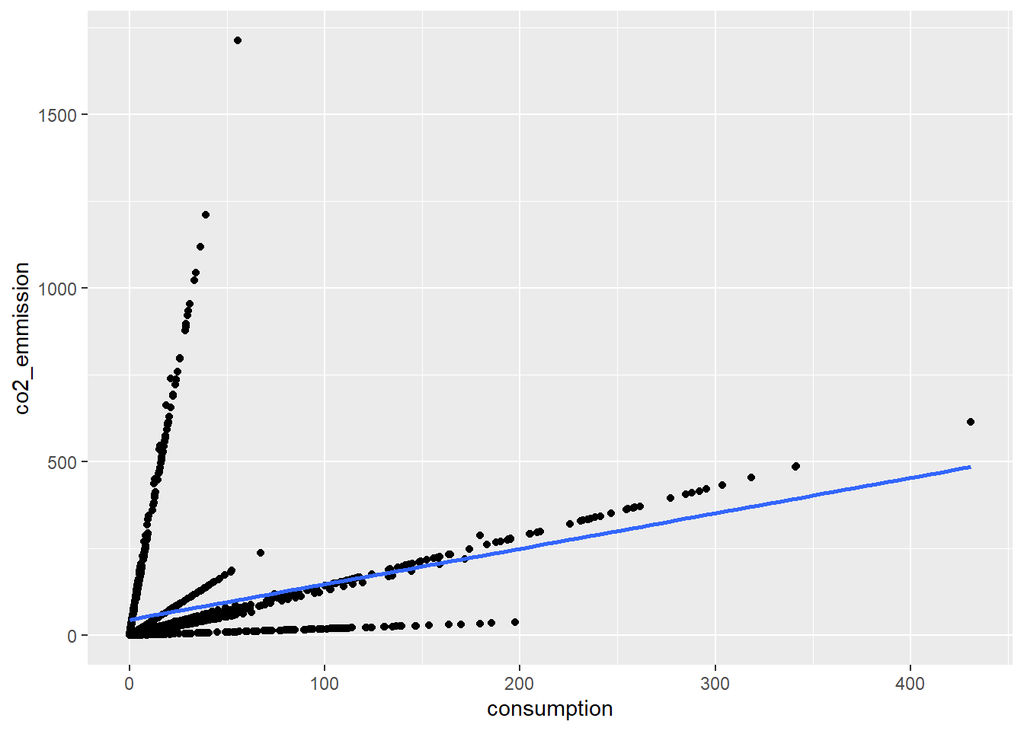

```r
food %>%
  ggplot(aes(consumption, co2_emmission)) +
  geom_point() +
  geom_smooth(method = lm, se = FALSE)
```

```r
# using ggplot and liner method functions to display the relation.
```

#### The slope of the line shows a positive relation between the consumption and the final co2_emmission.

### *Relation between the consumption and the final co2_emmission depending on food_category?*

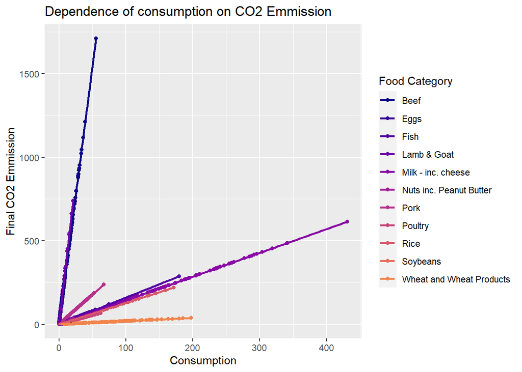

```r
food %>%
  ggplot(aes(consumption, co2_emmission, colour = food_category)) +
  geom_point() +
  geom_smooth(method = lm, se = FALSE) +
  scale_color_viridis_d(option = "plasma", end = .7) +
  labs(x = "Consumption", y = "Final CO2 Emmission", colour = "Food Category", title = "Dependence of consumption on CO2 Emmission")
```

## **Is emission of CO2 gas increased when consumption is increased?**

#### *Yes, If consumption is increased emission is increased.*

#### *Displaying CO2 Emmission For Each Food Category.*

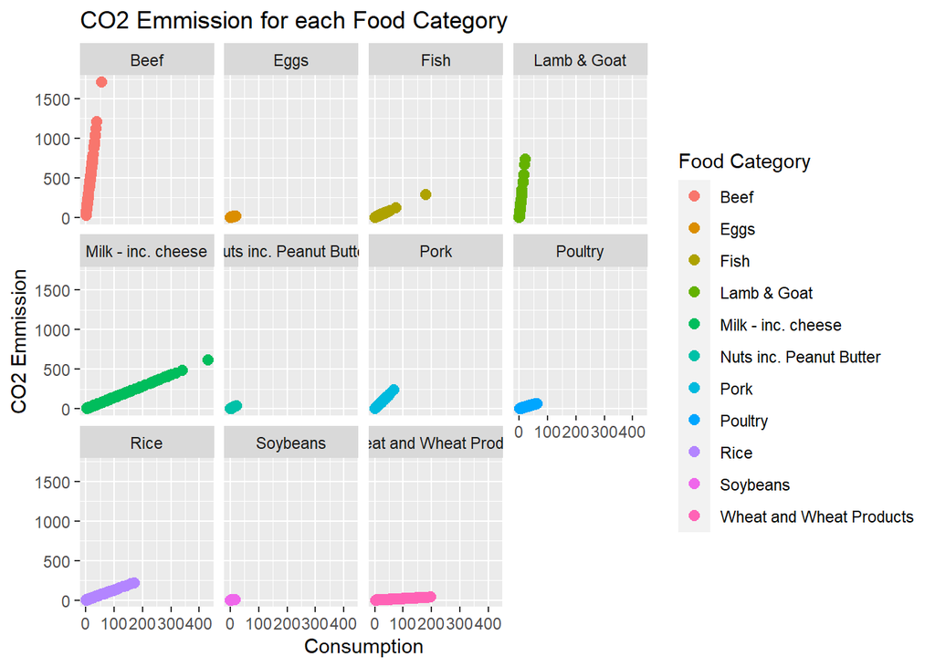

```r
food %>%
  ggplot(aes(consumption, co2_emmission, colour = food_category)) +
  geom_point(size = 2.5) +
  facet_wrap(~food_category)+
  labs(x = "Consumption", y = "CO2 Emmission", colour = "Food Category", title = "CO2 Emmission for each Food Category")
```

# **Solution:**

### *In order to reduce co2 emissions from food consumption people have to start consuming more green foods, plant based foods. Its fact that meat have good protiens but at the same time green foods also contain protiens. There is no need to ban meat but reducing the meat consumption can help us reduce c02 emmissions.*

# *Predictive Analysis*

#### From our descriptive analysis, we have found that the final co2emmission of the foodtype can be predicted by knowing their consumption and food_category. We will now build a model to make these predictions.

### **Step 1: Split the dataset into Training & Testing datasets.**

```r
food_split <- initial_split(food)

# splitting the data for training and testing purposes - on 3/4 data for training and 1/4 data for testing.

food_train <- training(food_split)

# training the data set

food_test <- testing(food_split)

# testing the data set
```

[output not shown]

### **2.2 Write the recipe steps - step_food()**

#### *Success of modelling depends on the “quality” of data. To ensure this quality, there are few transformations that are necessary in our dataset.*

#### *Whenever we have numeric values in our dataset, to avoid the outliers we need to normalise it by “Centering” & “Scalling” by using the functions - [step_center() & step_scale()]*

#### *We also need to remove any numeric variables that are closely related (=correlated) by using the function - [step_corr()]*

```r
food_recipe <- food_recipe %>%

  # Normalises numeric data to have a mean of zero

  step_center(all_numeric(), -all_outcomes()) %>%

  # Normalizes numeric data to have a standard deviation of one

  step_scale(all_numeric(), -all_outcomes()) %>%

  # removes variables that are too closely related

  step_corr(all_numeric())
```

### **2.3 Get ready with the prep by using function - prep()**

```r
food_prep <- prep(food_recipe, training = food_train)
```

### **2.4 Bake the recipe by using the function - bake()**

```r
food_bake <- bake(food_prep, food_train)

food_bake
```

```
## # A tibble: 1,072 x 3
##    food_category            consumption co2_emmission
##    <fct>                          <dbl>         <dbl>
##  1 Fish                          0.0196         44.6
##  2 Nuts inc. Peanut Butter      -0.558           0.87
##  3 Nuts inc. Peanut Butter      -0.521           3.95
##  4 Poultry                      -0.0859         24.6
##  5 Poultry                       0.118          35.0
##  6 Pork                         -0.0994         78.9
##  7 Wheat and Wheat Products      1.40           17.8
##  8 Wheat and Wheat Products      1.72           20.8
##  9 Lamb & Goat                  -0.549          32.2
## 10 Rice                          0.855          86.6
## # ... with 1,062 more rows
```

### **Step 3: Build a model**

#### *There are THREE important things to remember while building a model:*

#### *Model type [Linear Regression - linear_reg]*

#### *For this modelling, our Output variable is Numeric. So, we will use Regression.*

#### *In statistics, linear regression is a linear approach for modelling the relationship between a scalar response and one or more explanatory variables (also known as dependent and independent variables).

### **3.1 Set up the model [mode, model type & engine]**

```r
model1 <- linear_reg() %>%
  set_mode("regression") %>%
  set_engine("lm")

model1
```

```
## Linear Regression Model Specification (regression)
##
## Computational engine: lm
```

### **3.2 Fit the model**

```r
model1_fitted <- model1 %>%
  fit(co2_emmission ~ consumption * food_category, data = food_bake)

summary(model1_fitted)
```

```
##         Length Class      Mode
## lvl      0     -none-     NULL
## spec     5     linear_reg list
## fit     13     lm         list
## preproc  1     -none-     list
## elapsed  5     proc_time  numeric
```

### **Step 4: Create a workflow**

```r
workflow <- workflow() %>%
  add_recipe(food_recipe) %>%
  add_model(model1)

workflow
```

```
## == Workflow ====================================================================
## Preprocessor: Recipe
## Model: linear_reg()
##
## -- Preprocessor ----------------------------------------------------------------
## 3 Recipe Steps
##
## * step_center()
## * step_scale()
## * step_corr()
##
## -- Model -----------------------------------------------------------------------
## Linear Regression Model Specification (regression)
##
## Computational engine: lm
```